# IMDB caso di studio

Alessandro Aere

22 maggio 2020

```r
library(tensorflow)
use_session_with_seed(28)
```

```
## Set session seed to 28 (disabled GPU)
```

```r
library(keras)
install_keras()
```

## Caricamento dei dati

In seguito, definiamo due variabili necessarie per la *sentiment analysis*, o in generale l’analisi testuale:

- `max_features`: generalmente quando si effettua un’analisi testuale, si fa riferimento ad un vocabolario, ovvero una raccolta di parole ordinata secondo la frequenza in cui si presentano nel corpus di documenti; di queste parole vengono considerate solamente le *n* parole più frequenti, dove *n* è il valore associato alla variabile `max_features`; tutte le restanti parole vengono sostituite con un generico valore `2L`.
- `maxlen`: è la lunghezza massima di una frase; se una frase è più lunga del valore di questa variabile, verrà tagliata.

```r
max_features <- 10000
maxlen <- 500

imdb <- dataset_imdb(num_words = max_features)
c(c(x_train, train_labels), c(x_test, test_labels)) %<-% imdb
```

## Preparazione dei dati

Generalmente il primo step di preparazione è la **tokenizzazione**, ossia l’associazione di un numero intero a ciascuna parola. Questo step non è necessario, perchè in questo caso le sequenze sono già *tokenizzate*.

In seguito, defininiamo anche una funzione che servirà in seguito: `vectorize_sequences`. Questa funzione ha come scopo la trasformazione dell’intero dataset, effettuando la dicotomizzazione delle parole presenti nelle frasi.

```r
vectorize_sequences <- function(sequences, dimension = max_features) {
# Function that applies one-hot-encoding to the sequences.
# Input:
# - sequences: list of sequences; each sequence has length equal to the length of the sentence, and each int value of the sequence corresponds to a word.
# - dimension: max number of words to include; words are ranked by how often they occur (in the training set) and only the most frequent words are kept.
# Output:
# - results: matrix of dim = (n, dimension); each row represents a different sentence, and each column represents a different word; the matrix is filled by 0 and 1 values, depending if the word is present in that sentence or else.
results <- matrix(0, nrow = length(sequences), ncol = dimension)
for (i in 1:length(sequences)) results[i, sequences[[i]]] <- 1
return(results)
}

y_train <- as.numeric(train_labels)
y_test <- as.numeric(test_labels)
```

## Deep Neural Network

Specificare l’architettura della rete neurale:

- vengono utilizzati due layer *fully-connected*, il primo con $32$ nodi ed il secondo con $16$.
- viene utilizzata la funzione *ReLU* come funzione di attivazione negli strati latenti, e la funzione *logistica* nello strato di output.

```r
model <- keras_model_sequential() %>%
layer_dense(units = 32, activation = "relu", input_shape = c(max_features)) %>%
layer_dense(units = 16, activation = "relu") %>%
layer_dense(units = 1, activation = "sigmoid")

model
```

```
## Model
## Model: "sequential"
## ________________________________________________________________________________
## Layer (type)                        Output Shape                    Param #
## ================================================================================
## dense (Dense)                       (None, 32)                      320032
## ________________________________________________________________________________
## dense_1 (Dense)                     (None, 16)                      528
## ________________________________________________________________________________
## dense_2 (Dense)                     (None, 1)                       17
## ================================================================================
## Total params: 320,577
## Trainable params: 320,577
## Non-trainable params: 0
## ________________________________________________________________________________
```

Compilare il modello:

- l’ottimizzatore utilizzato è `rmsprop`, con un *learning rate* pari a $0.001$;
- viene utilizzata la *cross-entropia* come funzione di perdita, e l’*accuratezza* come metrica di valutazione.

```r
model %>% compile(
  optimizer = optimizer_rmsprop(lr = 0.001),
  loss = "binary_crossentropy",
  metrics = c("accuracy")
)
```

Effettuare il training della rete neurale. Come input alla rete neurale, diamo le sequenze dicotomizzate, applicando la funzione `vectorize_sequences` al dataset `x_train`.

```r
history <- model %>% fit(
  x = vectorize_sequences(x_train),
  y = y_train,
  epochs = 10,
  batch_size = 32,
  validation_split = 0.2,
  verbose = 1
)
```

In seguito viene rappresentato il grafico della funzione di perdita e dell’accuratezza in funzione del numero di epoche.

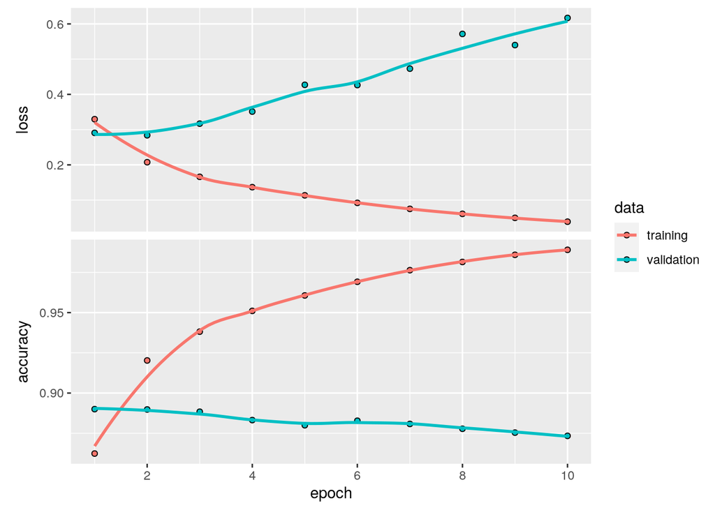

```r
plot(history)
```

Valutazione del modello sui dati di test.

```r
results <- model %>% evaluate(
  x = vectorize_sequences(x_test),
  y = y_test,
  verbose = 0
)

print(paste("Loss on test data:", results["loss"]))
```

```
## [1] "Loss on test data: 0.70270562171936"
```

```r
print(paste("Accuracy on test data:", results["accuracy"]))
```

```
## [1] "Accuracy on test data: 0.856880009174347"
```

# Recurrent neural network

Specificare l’architettura della rete neurale:

- Il primo strato è un layer di *embedding*, con il quale ogni parola viene trasformata in un vettore di dimensione pari a $128$
- Il secondo strato è un layer **LSTM**, una versione potenziata del layer ricorrente.

```r
model <- keras_model_sequential() %>%
layer_embedding(input_dim = max_features, output_dim = 128) %>%
layer_lstm(units = 32) %>%
layer_dense(units = 16, activation = "relu") %>%
layer_dense(units = 1, activation = "sigmoid")

model
```

```
## Model
## Model: "sequential_1"
## ________________________________________________________________________________
## Layer (type)                        Output Shape                    Param #
## ================================================================================
## embedding (Embedding)               (None, None, 128)               1280000
## ________________________________________________________________________________
## lstm (LSTM)                         (None, 32)                      20608
## ________________________________________________________________________________
## dense_3 (Dense)                     (None, 16)                      528
## ________________________________________________________________________________
## dense_4 (Dense)                     (None, 1)                       17
## ================================================================================
## Total params: 1,301,153
## Trainable params: 1,301,153
## Non-trainable params: 0
## ________________________________________________________________________________
```

Compilare il modello:

- l’ottimizzatore utilizzato è `rmsprop`, con un *learning rate* pari a $0.001$;
- viene utilizzata la *cross-entropia* come funzione di perdita, e l’*accuratezza* come metrica di valutazione.

```r
model %>% compile(
  optimizer = optimizer_rmsprop(lr = 0.001),
  loss = "binary_crossentropy",
  metrics = c("accuracy")
)
```

```r
history <- model %>% fit(
  x = pad_sequences(x_train, maxlen = maxlen),
  y = y_train,
  epochs = 10,
  batch_size = 32,
  validation_split = 0.2,
  verbose = 1
)
```

In seguito viene rappresentato il grafico della funzione di perdita e dell’accuratezza in funzione del numero di epoche.

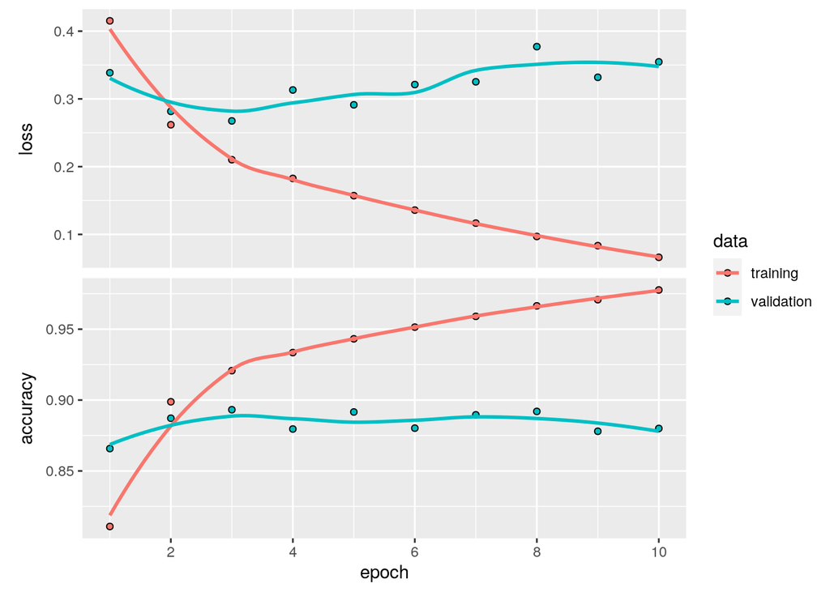

```r
plot(history)
```

Valutazione del modello sui dati di test.

```r
results <- model %>% evaluate(
  x = pad_sequences(x_test, maxlen = maxlen),
  y = y_test,
  verbose = 0
)

print(paste("Loss on test data:", results["loss"]))
```

```
## [1] "Loss on test data: 0.383068799972534"
```

```r
print(paste("Accuracy on test data:", results["accuracy"]))
```

```
## [1] "Accuracy on test data: 0.873480021953583"
```